# Predicting good exercise form from accelerometer data

Derwin McGeary

11/08/2015

## Background

Using devices such as Jawbone Up, Nike FuelBand, and Fitbit it is now possible to collect a large amount of data about personal activity relatively inexpensively. These type of devices are part of the quantified self movement – a group of enthusiasts who take measurements about themselves regularly to improve their health, to find patterns in their behavior, or because they are tech geeks. One thing that people regularly do is quantify how much of a particular activity they do, but they rarely quantify how well they do it. In this project, we want to use data from accelerometers on the belt, forearm, arm, and dumbell of 6 participants. They were asked to perform barbell lifts correctly and incorrectly in 5 different ways. More information is available from the website here: http://groupware.les.inf.puc-rio.br/har (see the section on the Weight Lifting Exercise Dataset).

## Data

The first stage is to obtain and process the data we are going to use. Firstly we take the training set.

```r
library(downloader)
library(caret)
```

```r
library(reshape2)

grabme <- function(URL,FILE)  {if(!file.exists(FILE)) {
  download(URL, FILE) }}

sourceurl <- "https://d396qusza40orc.cloudfront.net/predmachlearn/pml-training.csv"
grabme(sourceurl, "trainset.csv")
datas <- read.csv("trainset.csv")
```

We are operating on a low-RAM, single-core system, so we reduce as many variables as we can. Firstly we get rid of Near Zero Variance columns as these are unlikely to have predictive value.

```r
# strip Near Zero Variance columns
nzvcols <- nearZeroVar(datas)
datas <- datas[,-nzvcols]
```

We partition the training data into training and validation subsets.

```r
# Partition data
inTrain <- createDataPartition(y=datas$classe, p=0.75, list=F)
training <- datas[inTrain,]
validation <- datas[-inTrain,]
```

We should process our test data the same, and strip out the same columns

```r
testurl <- "https://d396qusza40orc.cloudfront.net/predmachlearn/pml-testing.csv"
grabme(testurl,"testset.csv")
testing <- read.csv("testset.csv")

# strip the *same* near zero columns out of testing
testing <- testing[,-nzvcols]
```

A function to strip out columns with more than 10% zeros. As computational power is limited we wish to keep only the most informative data.

```r
philtre <- function(datas) {
  datas <- datas[sapply(datas, function(x) !any(is.na(x)))]

  zerotest <<- NULL
  for(i in 1:length(datas))
  {
    zerotest <<- c(zerotest, nrow(datas[datas[,i] == 0,])/nrow(datas))
  }
  removecols <- colnames(datas[,which(zerotest >.10)])
  datas[,removecols] <- list(NULL)
  datas[datas == 0] <- NA
  datas <- datas[complete.cases(datas),]
  datas
}

training<-philtre(training)
```

## Feature selection and model building

### Acceleration model

We start by using only the the features with acceleration data, indicated by names starting with “accel” in the dataset. We use a RandomForest algorithm and we check for out of sample (OOS) error using the validation data.

```r
accset <- data.frame(training$classe,training[,grep("^accel", names(training))])
names(accset)[names(accset)=="training.classe"] <- "classe"

### the following line takes AGES (hours)on my machine
### so we load("accelonly.RData") instead if possible
if(!file.exists("accelmodel.RData"))
  {
  system.time(accmodel <- train(accset$classe ~ ., data=accset, preProcess="pca"))
  save(accmodel,file="accelmodel.RData")
  } else {
    load("accelmodel.RData")
  }

z <- confusionMatrix(validation$classe, predict(accmodel, validation))
```

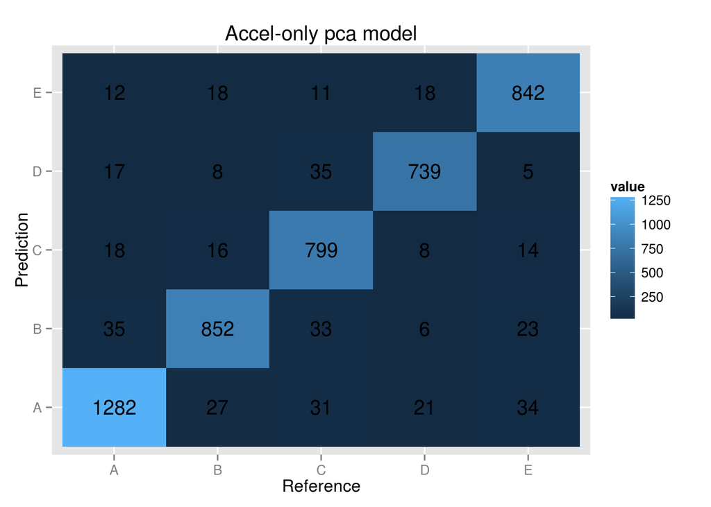

```r
cm <- z$table

ggplot(melt(cm),
       aes(Reference,
           Prediction,
           fill=value,
           label=value)) +
  geom_tile() +
  geom_text() + ggtitle("Accel-only pca model")
```

```r
print(accmodel)
```

```
## Random Forest
##
## 9764 samples
##   12 predictors
##    5 classes: 'A', 'B', 'C', 'D', 'E'
##
## Pre-processing: principal component signal extraction (12), centered
##  (12), scaled (12)
## Resampling: Bootstrapped (25 reps)
## Summary of sample sizes: 9764, 9764, 9764, 9764, 9764, 9764, ...
## Resampling results across tuning parameters:
##
##   mtry  Accuracy   Kappa      Accuracy SD  Kappa SD
##    2    0.8470059  0.8081912  0.005580592  0.006947559
##    7    0.8283181  0.7847510  0.007061970  0.008832666
##   12    0.8214318  0.7761248  0.007198300  0.008993367
##
## Accuracy was used to select the optimal model using  the largest value.
## The final value used for the model was mtry = 2.
```

```r
##################### End of accmodel ###########
```

### Gyroscope-only model

This model concentrates only on the gyroscope measurements, indicated by “gyro” in the column names of the dataset. As before, we use RandomForest and estimate our OOS error with the validation data.

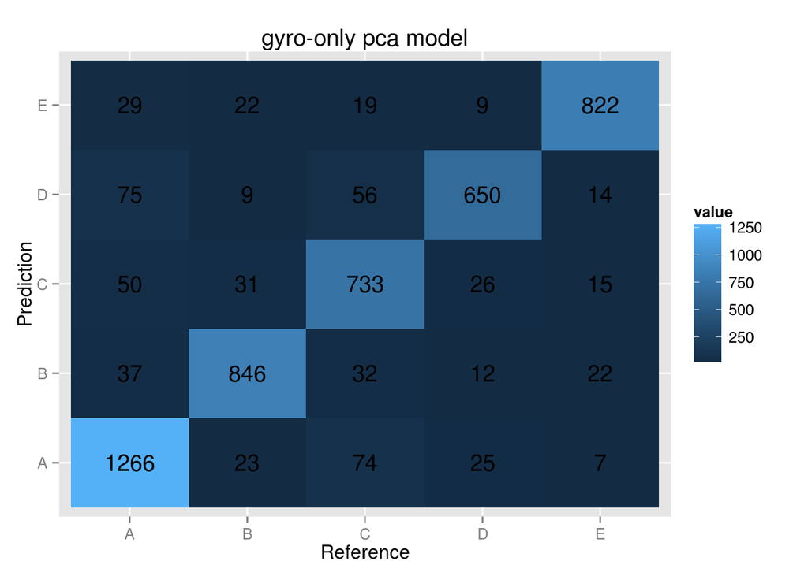

```r
gyroset <- data.frame(training$classe,training[,grep("^gyro", names(training))])
names(gyroset)[names(gyroset)=="training.classe"] <- "classe"

if(!file.exists("gyromodel.RData")) {
  system.time(gyromodel <- train(gyroset$classe ~ ., data=gyroset, preProcess="pca"))
  save(gyromodel,file="gyromodel.RData")
  } else {
    load("gyromodel.RData")
  }

z <- confusionMatrix(validation$classe, predict(gyromodel, validation))
cm <- z$table

ggplot(melt(cm),
       aes(Reference,
           Prediction,
           fill=value,
           label=value)) +
  geom_tile() +
  geom_text() + ggtitle("gyro-only pca model")
```

```r
print(gyromodel)
```

```
## Random Forest
##
## 9760 samples
##   11 predictors
##    5 classes: 'A', 'B', 'C', 'D', 'E'
##
## Pre-processing: principal component signal extraction (11), centered
##  (11), scaled (11)
## Resampling: Bootstrapped (25 reps)
## Summary of sample sizes: 9760, 9760, 9760, 9760, 9760, 9760, ...
## Resampling results across tuning parameters:
##
##   mtry  Accuracy   Kappa      Accuracy SD  Kappa SD
##    2    0.7560757  0.6931969  0.01450162   0.01819644
##    6    0.7379701  0.6705929  0.01386334   0.01736773
##   11    0.7316349  0.6626598  0.01366488   0.01713636
##
## Accuracy was used to select the optimal model using  the largest value.
## The final value used for the model was mtry = 2.
```

### Dumbell model

Finally this model was chosen because it may be practical to use only sensors which can remain attached to the equipment, giving the user more freedom. It uses only measurements with “dumbbell” in the name, indicating that the sensors were attached to the dumbbell.

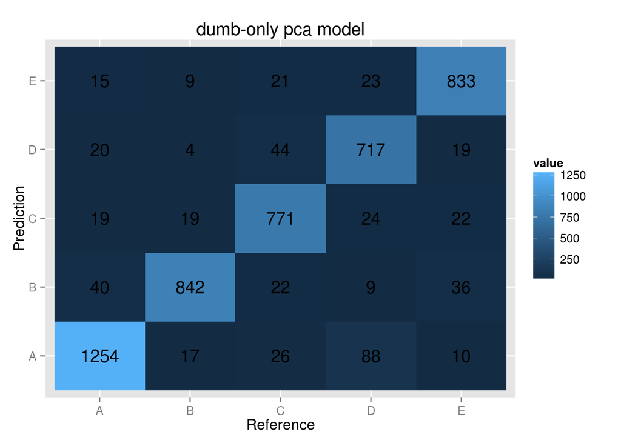

```r
dumbset <- data.frame(training$classe,training[,grep("dumbbell", names(training))])
names(dumbset)[names(dumbset)=="training.classe"] <- "classe"

if(!file.exists("gyromodel.RData")) {
  system.time(dumbmodel <- train(dumbset$classe ~ ., data=dumbset, preProcess="pca"))
  save(dumbmodel,file="dumbmodel.RData")
} else {
  load("dumbmodel.RData")
}

z <- confusionMatrix(validation$classe, predict(dumbmodel, validation))
cm <- z$table

ggplot(melt(cm),
       aes(Reference,
           Prediction,
           fill=value,
           label=value)) +
  geom_tile() +
  geom_text() + ggtitle("dumb-only pca model")
```

```r
print(dumbmodel)
```

```
## Random Forest
##
## 9760 samples
##   13 predictors
##    5 classes: 'A', 'B', 'C', 'D', 'E'
##
## Pre-processing: principal component signal extraction (13), centered
##  (13), scaled (13)
## Resampling: Bootstrapped (25 reps)
## Summary of sample sizes: 9760, 9760, 9760, 9760, 9760, 9760, ...
## Resampling results across tuning parameters:
##
##   mtry  Accuracy   Kappa      Accuracy SD  Kappa SD
##    2    0.8074807  0.7584317  0.006932721  0.008757640
##    7    0.7924103  0.7395639  0.007676471  0.009659137
##   13    0.7864688  0.7321025  0.009788806  0.012300578
##
## Accuracy was used to select the optimal model using  the largest value.
## The final value used for the model was mtry = 2.
```

## Combining models

As none of these were particularly good individually, I decided to try to increase the accuracy by using a simple voting model to combine the three. The acceleration model is the best, so we use the prediction from that unless the other two models both predict the same thing, in which case we take that value instead. This is a weighted majority-vote model.

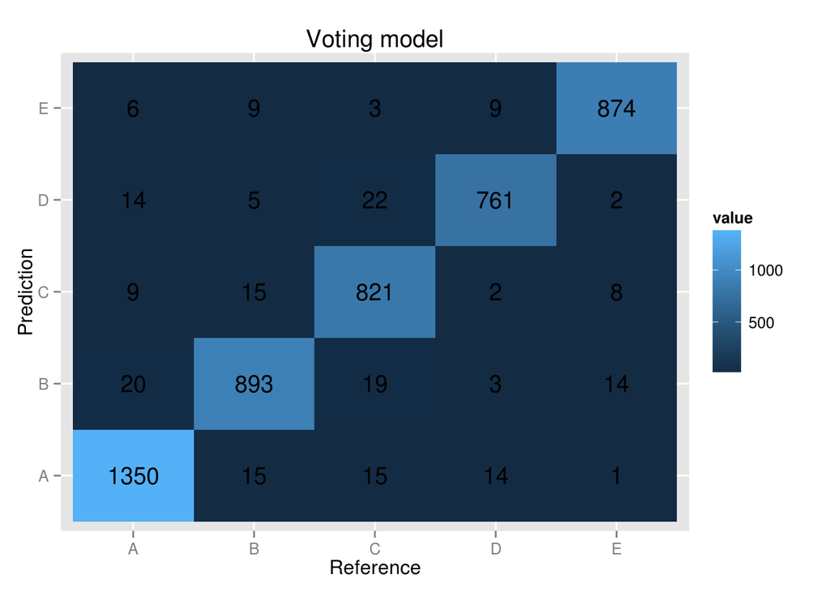

```r
total <- data.frame(acc=predict(accmodel,validation),gyro=predict(gyromodel,validation),dumb=predict(dumbmodel,validation),actual=validation$classe,voted=validation$classe)
total$voted <- ifelse(total$dumb==total$gyro,as.character(total$gyro),as.character(total$acc))
z <- confusionMatrix(total$actual,total$voted)
cm <- z$table
ggplot(melt(cm),
aes(Reference,
Prediction,
fill=value,
label=value)) +
geom_tile() +
geom_text() + ggtitle("Voting model")
```

```r
print(estimated_accuracy <- sum(total$voted==total$actual)/length(total$voted)*100)
```

```
## [1] 95.81974
```

This gives an estimated accuracy on the validation set of 96 % which is an improvement on the acceleration model.

# Appendix

## Results submission

```r
results <- data.frame(acc=predict(accmodel,testing),
                      gyro=predict(gyromodel,testing),
                      dumb=predict(dumbmodel,testing),
                      voted=predict(dumbmodel,testing))

results$voted <- ifelse(results$dumb==results$gyro,
                        as.character(results$gyro),
                        as.character(results$acc))

pml_write_files = function(x){
  n = length(x)
  for(i in 1:n){
    filename = paste0("problem_id_",i,".txt")
    write.table(x[i],file=filename,quote=FALSE,row.names=FALSE,col.names=FALSE)
    }
  }
pml_write_files(results$voted)
```